# Correspondence and Network Analysis of Obesity-Related Data

TURRI Valentín

2025-05-10

## 1. Data

We start by reading the data. The goal is to perform a correspondence analysis to explore relationships between weight and age.

```r
# Read CSV file
path <- "C:/Users/valen/OneDrive/Escritorio/Maestría en Ciencia de Datos/AID/TP4/obesidad.csv"
obesity_stats <- read_csv(path, locale = locale(encoding = "UTF-8"))
# Random sample of 500 cases
set.seed(920)
obesity_sample <- obesity_stats %>% sample_n(500)

str(obesity_sample)
```

```
## spc_tbl_ [500 × 18] (S3: spec_tbl_df/tbl_df/tbl/data.frame)
##  $ id                            : num [1:500] 5801 2535 139 20289 20563 ...
##  $ Gender                        : chr [1:500] "Male" "Female" "Female" "Female" ...
##  $ Age                           : num [1:500] 21 26 19.6 33 18 ...
##  $ Height                        : num [1:500] 1.62 1.64 1.5 1.65 1.6 ...
##  $ Weight                        : num [1:500] 70 104.9 71.6 77 45 ...
##  $ family_history_with_overweight: chr [1:500] "no" "yes" "yes" "no" ...
##  $ FAVC                          : chr [1:500] "no" "yes" "no" "yes" ...
##  $ FCVC                          : num [1:500] 2 3 3 3 3 ...
##  $ NCP                           : num [1:500] 3 3 3.09 3 3 ...
##  $ CAEC                          : chr [1:500] "no" "Sometimes" "Sometimes" "Sometimes" ...
##  $ SMOKE                         : chr [1:500] "no" "no" "no" "no" ...
##  $ CH2O                          : num [1:500] 3 2.58 2 2 2 ...
##  $ SCC                           : chr [1:500] "no" "no" "no" "no" ...
##  $ FAF                           : num [1:500] 1 0 1.08 0 1 ...
##  $ TUE                           : num [1:500] 0 0.402 1 1 2 ...
##  $ CALC                          : chr [1:500] "no" "Sometimes" "no" "Sometimes" ...
##  $ MTRANS                        : chr [1:500] "Public_Transportation" "Public_Transportation" "Public_Transportation" "Automobile" ...
##  $ NObeyesdad                    : chr [1:500] "Overweight_Level_I" "Obesity_Type_III" "Overweight_Level_II" "Overweight_Level_II" ...
##  - attr(*, "spec")=
##   .. cols(
##   ..   id = col_double(),
##   ..   Gender = col_character(),
##   ..   Age = col_double(),
##   ..   Height = col_double(),
##   ..   Weight = col_double(),
##   ..   family_history_with_overweight = col_character(),
##   ..   FAVC = col_character(),
##   ..   FCVC = col_double(),
##   ..   NCP = col_double(),
##   ..   CAEC = col_character(),
##   ..   SMOKE = col_character(),
##   ..   CH2O = col_double(),
##   ..   SCC = col_character(),
##   ..   FAF = col_double(),
##   ..   TUE = col_double(),
##   ..   CALC = col_character(),
##   ..   MTRANS = col_character(),
##   ..   NObeyesdad = col_character()
##   .. )
##  - attr(*, "problems")=<externalptr>
```

```r
obesity_sample <- obesity_sample %>%
  mutate(
    Weight_cat = cut(
      Weight,
      breaks = c(0, 50, 70, 90, 200),
      labels = c("Low", "Normal", "High", "Very High"),
      right = FALSE
    ),
    Age_cat = cut(
      Age,
      breaks = c(0, 18, 30, 50, 100),
      labels = c("Young", "Young Adult", "Adult", "Older"),
      right = FALSE
    )
  )
```

A contingency table is created.

```r
# Create contingency table
weight_age_table <- table(obesity_sample$Weight_cat, obesity_sample$Age_cat)

# Display table
kable(weight_age_table, caption = "Contingency table: Categorized Weight vs. Categorized Age")
```

Contingency table: Categorized Weight vs. Categorized Age

|  | Young | Young Adult | Adult | Older |
| --- | --- | --- | --- | --- |
| Low | 6 | 31 | 0 | 0 |
| Normal | 14 | 87 | 5 | 0 |
| High | 7 | 92 | 33 | 0 |
| Very High | 3 | 185 | 37 | 0 |

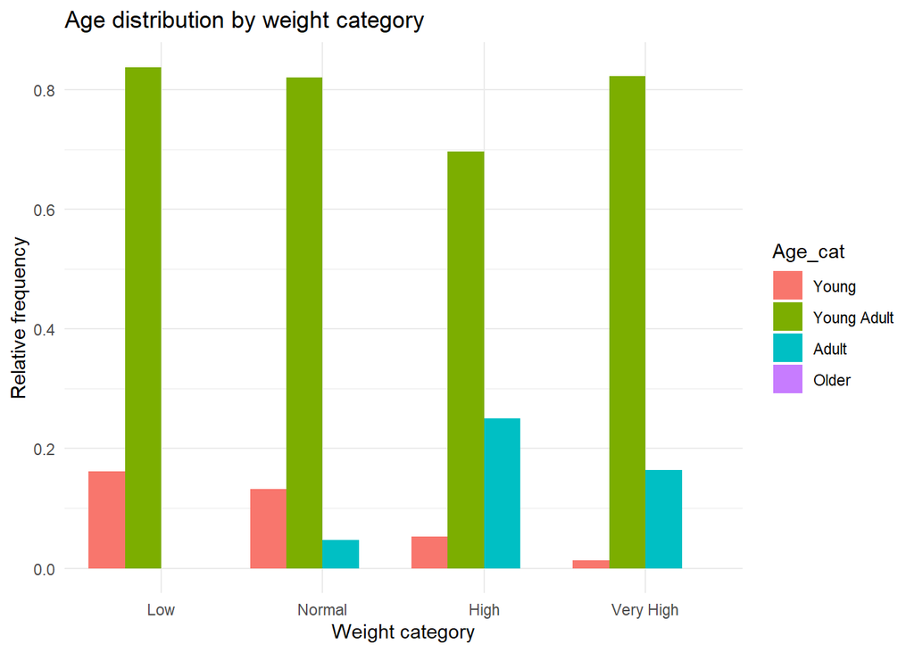

```r
# Relative table (row proportions)
relative_table <- prop.table(weight_age_table, margin = 1)
relative_table_df <- as.data.frame(relative_table)
colnames(relative_table_df) <- c("Weight_cat", "Age_cat", "Relative_frequency")

# Bar chart
ggplot(relative_table_df, aes(x = Weight_cat, y = Relative_frequency, fill = Age_cat)) +
  geom_bar(stat = "identity", position = "dodge") +
  labs(
    title = "Age distribution by weight category",
    x = "Weight category",
    y = "Relative frequency"
  ) +
  theme_minimal()
```

A Chi-square independence test is performed to assess whether there is independence between the selected variables.

```r
# Remove columns with all zeros (if any)
weight_age_table_filtered <- weight_age_table[, colSums(weight_age_table) > 0]

# Chi-square test (suppress warnings to avoid knit warnings, if desired)
chi_test <- suppressWarnings(chisq.test(weight_age_table_filtered))

# Show p-value in scientific notation
cat(paste0("**p-value (Chi-square):** ", format(chi_test$p.value, scientific = TRUE), "<br>"))
```

```
## **p-value (Chi-square):** 1.182408e-08<br>
```

The p-value is very small, so the data suggest some degree of dependence.

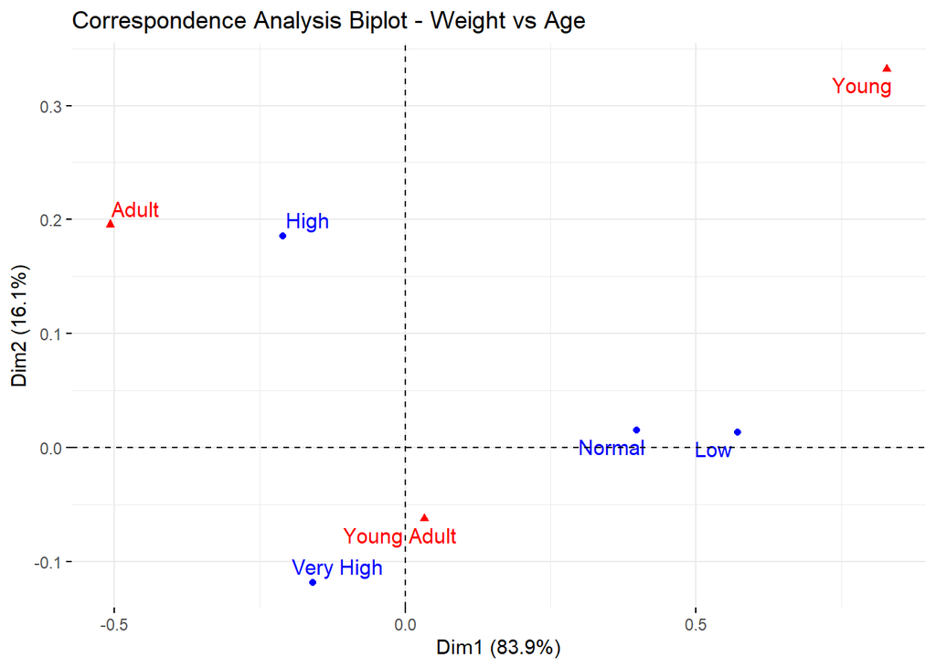

```r
# Simple Correspondence Analysis (CA)
ca_result <- CA(weight_age_table_filtered, graph = FALSE)

# Biplot
fviz_ca_biplot(ca_result, repel = TRUE) +
  ggtitle("Correspondence Analysis Biplot - Weight vs Age")
```

**Interpretation (CA):**

- “Young” appears clearly separated in the upper-right quadrant, associated with “Low” and “Normal” weight categories, indicating that younger individuals tend to have lower weights.
- “Young Adult” and “Very High” are positioned close to each other, suggesting that individuals in that age group more frequently present very high weights.
- “Adult” appears relatively close to the “High” category, indicating some association between these two.
- “Normal” and “Low” are fairly close, which may indicate there is no strong age differentiation among individuals in those weight categories.
- Dimension 1 mainly separates weight levels (from “Very High” to “Low”), while Dimension 2 captures smaller differences, likely related to age extremes such as “Adult” and “Young”.

```r
# Select only categorical columns for MCA
mca_vars <- obesity_sample %>%
  select(SMOKE, Gender, family_history_with_overweight, MTRANS)

# Display the first rows
head(mca_vars)
```

```
## # A tibble: 6 × 4
##   SMOKE Gender family_history_with_overweight MTRANS
##   <chr> <chr>  <chr>                          <chr>
## 1 no    Male   no                             Public_Transportation
## 2 no    Female yes                            Public_Transportation
## 3 no    Female yes                            Public_Transportation
## 4 no    Female no                             Automobile
## 5 no    Female no                             Public_Transportation
## 6 no    Male   no                             Public_Transportation
```

```r
# Apply MCA
mca_result <- MCA(mca_vars, graph = FALSE)
```

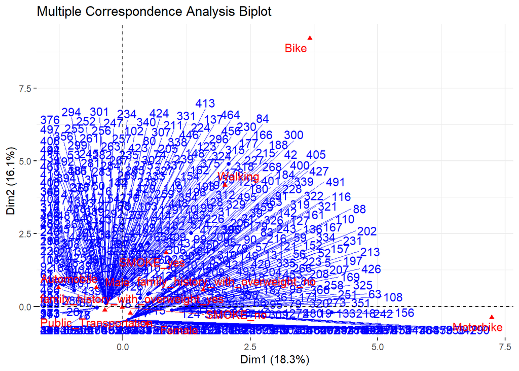

```r
# Visualize MCA biplot
fviz_mca_biplot(
  mca_result,
  repel = TRUE,
  ggtheme = theme_minimal()
) +
  ggtitle("Multiple Correspondence Analysis Biplot")
```

```r
# Variable contributions to Dimension 1
cat("Contributions to Dimension 1:\n")
```

```
## Contributions to Dimension 1:
```

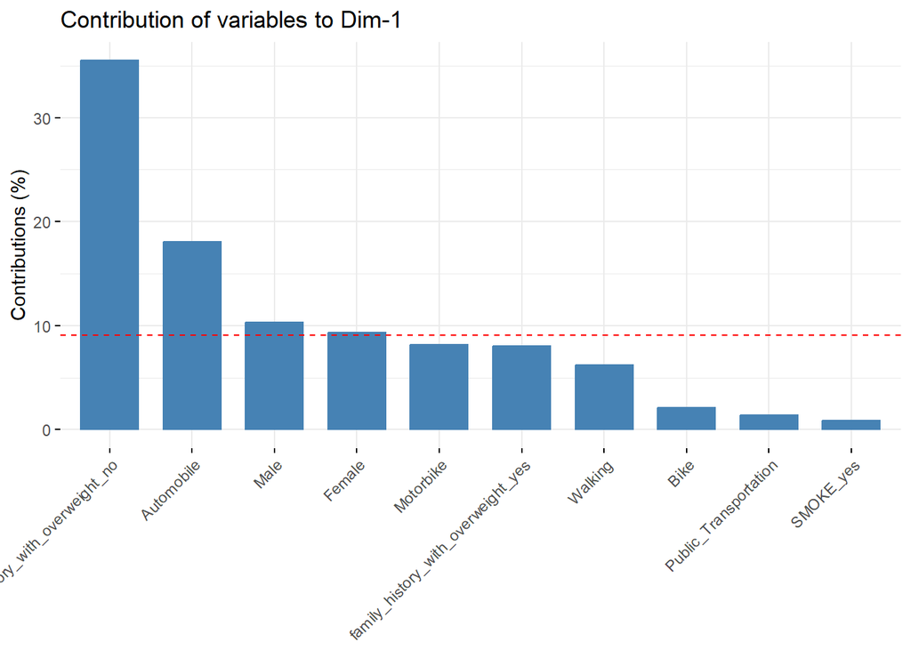

```r
print(fviz_contrib(mca_result, choice = "var", axes = 1, top = 10))
```

```r
# Variable contributions to Dimension 2
cat("Contributions to Dimension 2:\n")
```

```
## Contributions to Dimension 2:
```

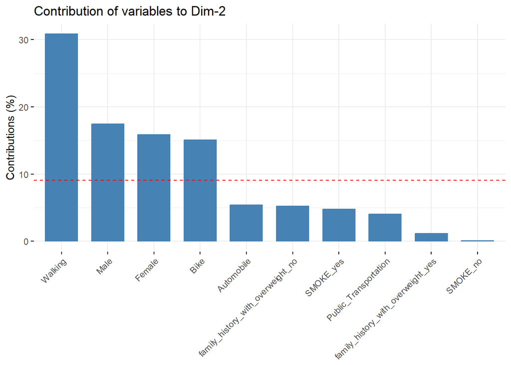

```r
print(fviz_contrib(mca_result, choice = "var", axes = 2, top = 10))
```

### Interpretation (MCA)

**1. Multiple Correspondence Analysis Biplot**  
The biplot shows the projection of individuals (blue) and variable categories (red) onto the first two MCA dimensions.

**3. Contribution to Dimension 2**  
For Dimension 2, the most influential categories are `MTRANS_Walking` (~30%), followed by `Gender_Male` (~18%), `Gender_Female` (~17%), and `MTRANS_Bike` (~16%). This dimension seems to reflect a combination of gender and preference for more accessible/active transportation (e.g., walking). The strong loading of `MTRANS_Walking` suggests this dimension could be interpreted as representing preference or access to less motorized transportation, differentiating certain gender and behavior profiles.